# Script 2: Étude

### 1.6.2.2 Carte lissée des prix de l’immobilier au m² calculés à partir des valeurs agrégées par section cadastrale sur l’ensemble de Tours Métropole

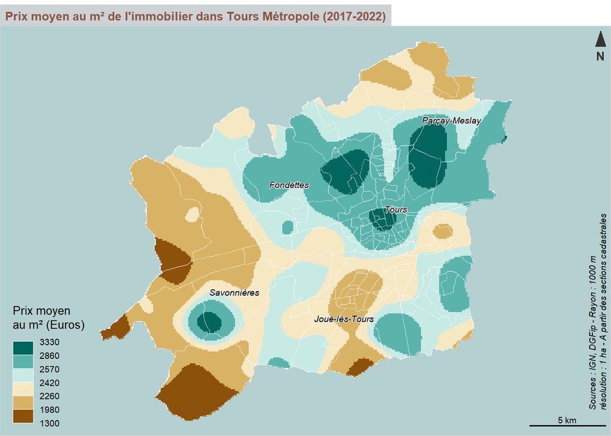

```r
# pour définir le contour de Tours Métropole comme emprise pour le lissage (sinon le lissage est calculé sur une fenêtre rectangulaire)
EmpriseTM <- as.owin(st_geometry(IRISTM))

# pour récupérer les coordonnées du centroïde des sections
pts <- st_coordinates(st_point_on_surface(st_geometry(SectionsDVF)))

# pour créer un objet ppp (format spatstat) et y intégrer dedans l'emprise et les valeurs à lisser (prix au m²)
Sections.ppp <- ppp(pts[,1], pts[,2], window = EmpriseTM, marks = SectionsDVF$prixm2)

# pour calculer la surface lissée (rayon lissage : 1 km et resolution spatiale de l'image : 1 ha)
cartelissee <- Smooth(Sections.ppp, sigma = 1000, weights = Sections.ppp$marks, eps = 100)

# Conversion de la surface lissée au format raster
cartelissee.raster <- terra::rast(cartelissee)
crs(cartelissee.raster) <- st_crs(Communes)$srid

# Paramétrage des marges de la fenêtre pour maximiser l'emprise de la carte
par(mar = c(0, 0, 1.5, 0))

# pour afficher la surface lissée et définir l'habillage
# Calcul des seuils
bks <- unique(getBreaks(values(cartelissee.raster), method = "q6"))

# Création d'une palette de couleurs (double gradation harmonique)
cols <- c("#8c510a", "#d8b365", "#f6e8c3", "#c7eae5", "#5ab4ac", "#01665e")

# Affichage des communes de TM et alentours en arrière-plan et centrage de la carte sur Tours Métropole
plot(st_geometry(Communes), lwd = 0.1, col = "grey95", border = "white", bg = "#B5D0D0", xlim = c(st_bbox(IRISTM)[1], st_bbox(IRISTM)[3]), ylim = c(st_bbox(IRISTM)[2], st_bbox(IRISTM)[4]))

# Affichage de la carte lissée et du contour des sections
plot(cartelissee.raster, breaks = bks, col = cols, add = T, legend = F)
plot(IRISDVF$geom, border = "white", lwd = 0.05, lty = 3, add = T)

legendChoro(
  pos = "bottomleft",
  title.txt = "Prix moyen \nau m² (Euros)",
  breaks = bks,
  nodata = FALSE,
  values.rnd = -1,
  border = "white",
  col = cols
)

layoutLayer(title = "Prix moyen au m² de l'immobilier dans Tours Métropole (2017-2022)",
            author = "         Sources : IGN, DGFip - Rayon : 1000 m\n         résolution : 1 ha - A partir des sections cadastrales",
            scale = 5, frame = TRUE, col = "#cdd2d4", coltitle = "#8A5543",
            north = TRUE, tabtitle = TRUE, horiz = FALSE)

# Ajouter les étiquettes des communes sélectionnées plus haut
labelLayer(Selection_Communes_TM, txt = "commune", halo = TRUE, bg = "grey90", r = 0.05, cex = 0.6, pos = 3, font = 3, offset = 0)
```

## 1.6.3 Lissage spatial des prix de l’immobilier au m² calculés directement à partir des mutations immobilières sur l’ensemble de Tours Métropole

### 1.6.3.1 Calcul de la distance au plus proche voisin et de l’auto-corrélation spatiale des prix au m²

```r
# Calcul sur les plus proches voisins
listPPV <- knearneigh(MutationsTM, k = 1) # pour connaître le plus proche voisin de chaque mutation
PPV <- knn2nb(listPPV, row.names = MutationsTM$id) # pour convertir l'objet knn en objet nb
distPPV <- nbdists(PPV, MutationsTM) # pour connaître la distance entre plus proches voisins
print(as.data.frame(t(as.matrix(summary(unlist(distPPV))))))
```

```
##   Min. 1st Qu. Median     Mean  3rd Qu.     Max.
## 1    0       0      0 13.47838 17.28297 1530.946
```

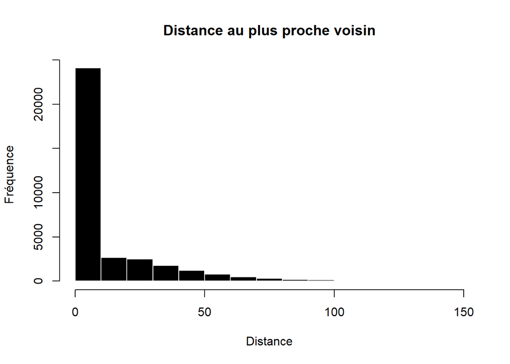

```r
hist(unlist(distPPV), nclass = 200,
     main = "Distance au plus proche voisin",
     col = "black", border = "white", xlab = "Distance", ylab = "Fréquence", xlim = c(0,150))
```

```r
#calcul du test de Moran
moran.test(MutationsTM$prixm2, listw = nb2listw(PPV))
```

```
##
##  Moran I test under randomisation
##
## data:  MutationsTM$prixm2
## weights: nb2listw(PPV)
##
## Moran I statistic standard deviate = 69.903, p-value < 2.2e-16
## alternative hypothesis: greater
## sample estimates:
## Moran I statistic       Expectation          Variance
##      4.407931e-01     -2.885836e-05      3.976779e-05
```

### 1.6.3.2 Carte lissée des prix de l’immobilier au m² calculés directement à partir des mutations immobilières sur l’ensemble de Tours Métropole

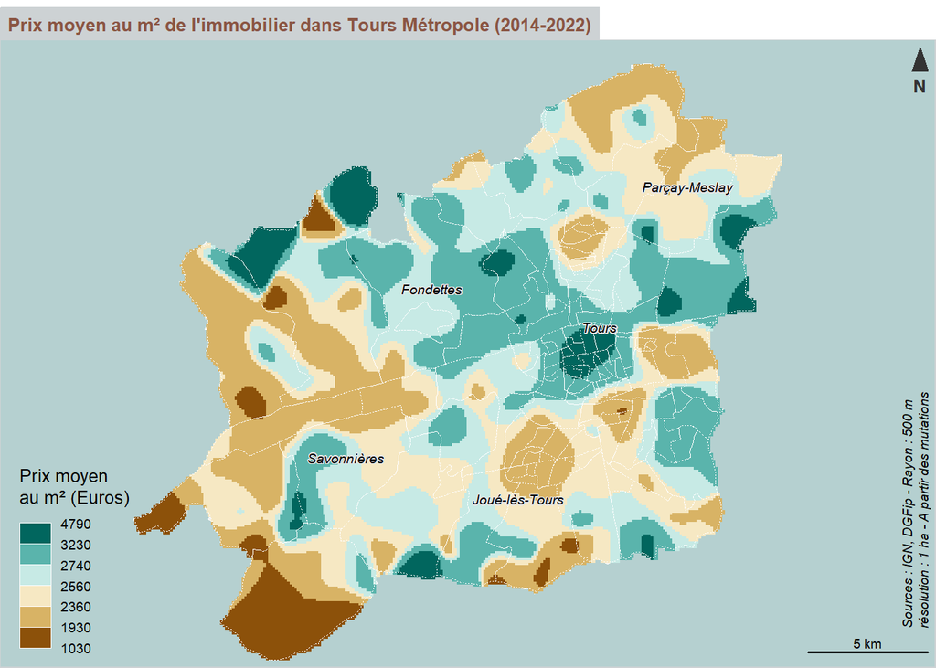

```r
# pour définir comme emprise pour le lissage, l'étendue de Tours métropole avec une zone tampon de 0,5 km autour afin d'englober les mutations limitrophes et réduire l'effet de bord
EmpriseTM.ZT <- as.owin(st_geometry(st_buffer(IRISTM, 500)))

# Extraction des coordonnées spatiales
coordinates <- st_coordinates(MutationsTM)

# pour créer un objet ppp (format spatstat) et y intégrer dedans l'emprise et les valeurs à lisser (prix moyen au m²)

MutationsTM.ppp <- ppp(x = coordinates[, 1], y = coordinates[, 2], window = EmpriseTM.ZT, marks = MutationsTM$prixm2)

# pour calculer la surface lissée (rayon lissage : 0,5 km et résolution spatiale de l'image : 1 ha) --> calcul long
cartelissee <- Smooth(MutationsTM.ppp, sigma = 500, weights = MutationsTM.ppp$marks, eps = 100)

# Conversion de la surface lissée au format raster
cartelissee.raster <- terra::rast(cartelissee)
crs(cartelissee.raster) <- st_crs(Communes)$srid

# découpage de la surface lissée sur l'emprise Tours Métropole
cartelissee.raster <- mask(cartelissee.raster, IRISTM)

# Paramétrage des marges de la fenêtre pour maximiser l'emprise de la carte
par(mar = c(0, 0, 1.5, 0))

# pour afficher la surface lissée et définir l'habillage de la carte
# Calcul des seuils
bks <- unique(getBreaks(values(cartelissee.raster), method = "q6"))

# Création d'une palette de couleurs (double gradation harmonique)
cols <- c("#8c510a", "#d8b365", "#f6e8c3", "#c7eae5", "#5ab4ac", "#01665e")

# Affichage des communes de RM et alentours en arrière-plan et centrage de la carte sur Tours Métropole
plot(st_geometry(Communes), lwd = 0.1, col = "grey95", border = "white", bg = "#B5D0D0", xlim = c(st_bbox(SectionsDVF)[1], st_bbox(SectionsDVF)[3]), ylim = c(st_bbox(SectionsDVF)[2], st_bbox(SectionsDVF)[4]))

# Affichage de la carte lissée et du contour des IRIS
plot(cartelissee.raster, breaks = bks, col = cols, add = T, legend = F)
plot(IRISTM$geom, border = "white", lwd = 0.05, lty = 3, add = T)

legendChoro(
  pos = "bottomleft",
  title.txt = "Prix moyen \nau m² (Euros)",
  breaks = bks,
  nodata = FALSE,
  values.rnd = -1,
  border = "white",
  col = cols
)

layoutLayer(title = "Prix moyen au m² de l'immobilier dans Tours Métropole (2014-2022)",
            author = "         Sources : IGN, DGFip - Rayon : 500 m\n         résolution : 1 ha - A partir des mutations",
            scale = 5, frame = TRUE, col = "#cdd2d4", coltitle = "#8A5543",
            north = TRUE, tabtitle = TRUE, horiz = FALSE)

# Ajouter les étiquettes des communes sélectionnées plus haut
labelLayer(Selection_Communes_TM, txt = "commune", halo = TRUE, bg = "grey90", r = 0.05, cex = 0.6, pos = 3, font = 3, offset = 0)
```

# 1.7 Elaboration d’une typologie à partir d’indicateurs immobiliers et cartographie des sous-marchés associés (échelle métropolitaine)

## 1.7.1 Transfert d’attributs des Iris vers les mutations (jointure spatiale)

```r
MutationsIRIS <- MutationsTM %>% st_join(IRISTM)
MutationsIRIS <- as.data.frame(MutationsIRIS)
```

## 1.7.2 Création d’un tableau avec les variables par Iris à soumettre à la CAH

```r
IRISDVFClassif1 <- MutationsIRIS %>% group_by(iris_code) %>%
  summarise(Nbtransactions = n(),
            Prixmoyen = round(mean(prix)),
            Prixm2moyen = round(mean(prixm2)),
            Surfacemoyenne = round(mean(surface)),
            PropMaison = length(type[type == "Maison"]) / Nbtransactions * 100,
            PropAppart = length(type[type == "Appartement"]) / Nbtransactions * 100)

IRISDVFClassif <- data.frame(IRISDVFClassif1[, c("Nbtransactions", "Prixmoyen", "Prixm2moyen", "Surfacemoyenne", "PropMaison", "PropAppart")])
```

## 1.7.3 Centrage et réduction des variables

```r
IRISDVFClassifScale <- scale(IRISDVFClassif)
```

## 1.7.4 Mise en oeuvre de la CAH

```r
CAHIRIS <- agnes(IRISDVFClassifScale,
                     metric = "euclidean",
                     method = "ward")
```

## 1.7.5 Graphiques des gains d’inertie inter-classe

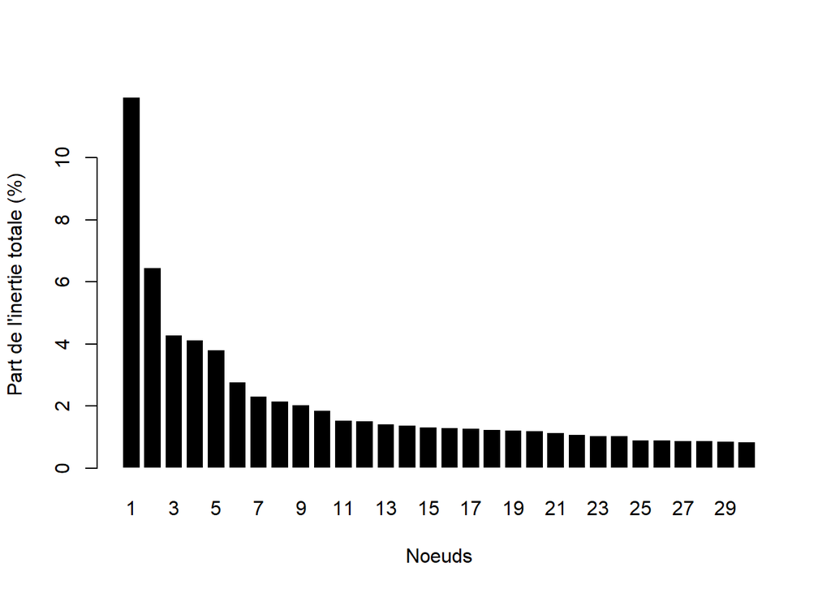

```r
sortedHeight<- sort(CAHIRIS$height, decreasing = TRUE)
relHeight<-sortedHeight/ sum(sortedHeight) * 100
cumHeight<- cumsum(relHeight)

barplot(relHeight[1:30], names.arg = seq(1, 30, 1), col = "black", border = "white", xlab = "Noeuds", ylab = "Part de l'inertie totale (%)")
```

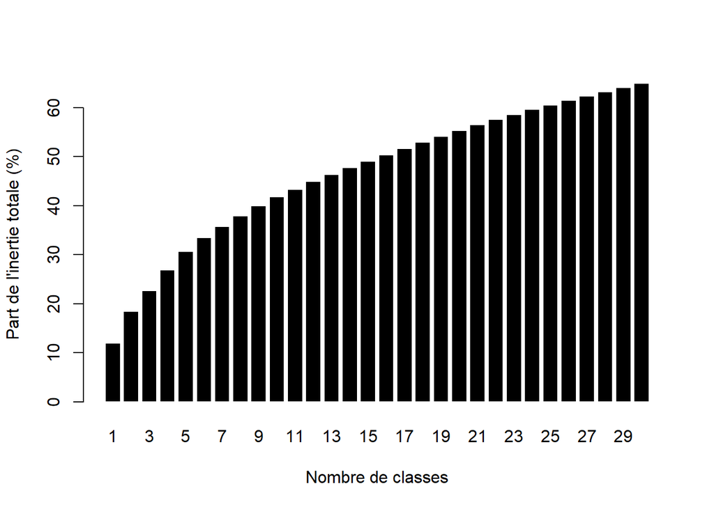

```r
barplot(cumHeight[1:30], names.arg = seq(1, 30, 1), col = "black", border = "white", xlab = "Nombre de classes", ylab = "Part de l'inertie totale (%)")
```

## 1.7.6 Arbre de classification hiérarchique

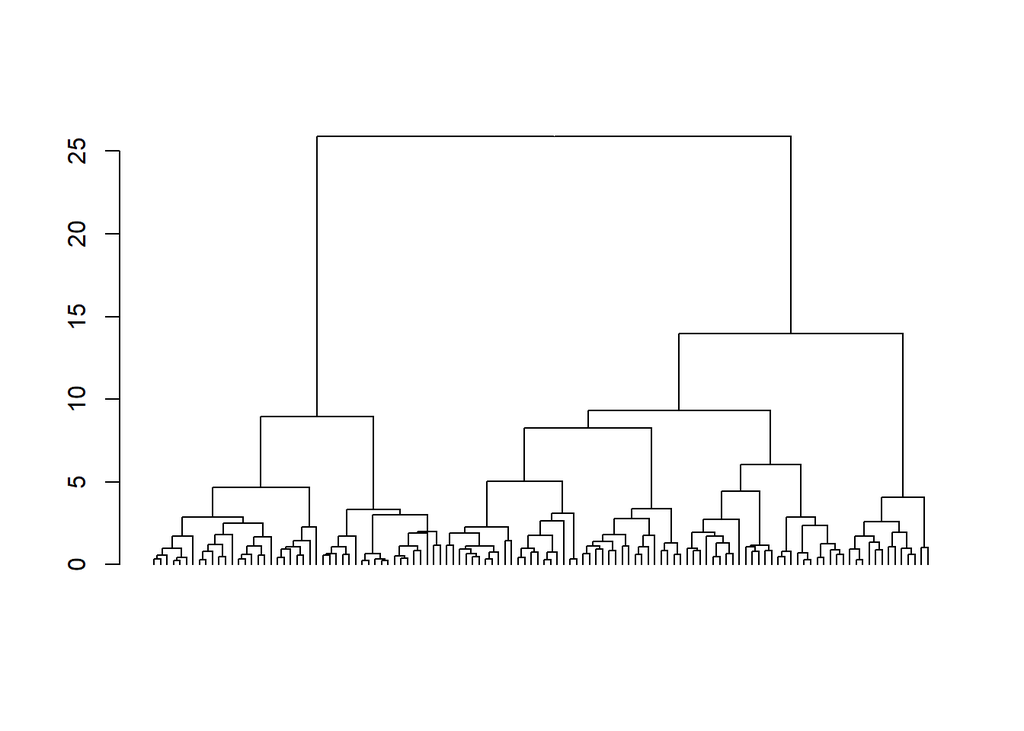

```r
dendroCSP <- as.dendrogram(CAHIRIS)
plot(dendroCSP, leaflab = "none")
```

## 1.7.7 Partition (en n classes)

```r
clusIRIS <- cutree(CAHIRIS, k = 5)
IRISCluster <- IRISDVFClassif1
IRISCluster$CLUSIMMO <- factor(clusIRIS,
                                   levels = 1:5,
                                   labels = paste("Classe", 1:5))
```

## 1.7.8 Création d’un tableau avec les caractéristiques des groupes

```r
RecapCAHIRIS <- IRISCluster %>% group_by(CLUSIMMO) %>% summarise(NB= n(), NbTransac = round(mean(Nbtransactions)), Prixmoyen = round(mean(Prixmoyen)), Prixm2 = round(mean(Prixm2moyen)), Surface = round(mean(Surfacemoyenne)), PropMaison = mean(PropMaison), PropAppart = mean(PropAppart))

print(RecapCAHIRIS)
```

```
## # A tibble: 5 × 8
##   CLUSIMMO    NB NbTransac Prixmoyen Prixm2 Surface PropMaison PropAppart
##   <fct>    <int>     <dbl>     <dbl>  <dbl>   <dbl>      <dbl>      <dbl>
## 1 Classe 1    26       249    263202   2466     109      90.9        9.06
## 2 Classe 2    19       132    185188   2146      89      89.1       10.9
## 3 Classe 3    37       378    148826   2215      68      31.6       68.4
## 4 Classe 4    13       128     90118   1561      61       5.48      94.5
## 5 Classe 5    25       400    197109   2884      68      27.1       72.9
```

## 1.7.9 Graphique des écarts à la moyenne

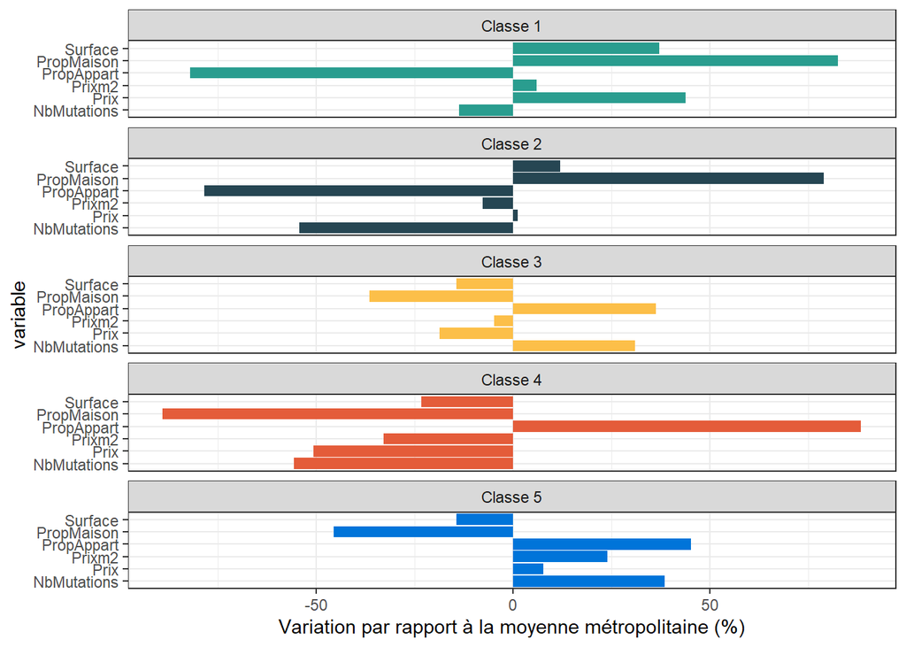

```r
SyntheseCAHIRIS <- RecapCAHIRIS %>% mutate(
  nbtransacmoy = mean(IRISDVFClassif$Nbtransactions),
  surfacemoy = mean(IRISDVFClassif$Surfacemoyenne),
  prixmoy = mean(IRISDVFClassif$Prixmoyen),
  prixm2moyen = mean(IRISDVFClassif$Prixm2moyen),
  propmaisonmoyen = mean(IRISDVFClassif$PropMaison),
  propappartmoyen = mean(IRISDVFClassif$PropAppart),
  NbMutations = (NbTransac - nbtransacmoy) / nbtransacmoy * 100,
  Prix = (Prixmoyen - prixmoy) / prixmoy * 100,
  Prixm2 = (Prixm2 - prixm2moyen) / prixm2moyen * 100,
  Surface = (Surface - surfacemoy) / surfacemoy * 100,
  PropMaison = (PropMaison - propmaisonmoyen) / propmaisonmoyen * 100,
  PropAppart = (PropAppart - propappartmoyen) / propappartmoyen * 100
)

# pour créer un nouveau tableau avec une sélection de colonnes à faire apparaître sur le graphique
SyntheseCAHIRIS <- data.frame(SyntheseCAHIRIS[, c("CLUSIMMO", "NbMutations", "Surface", "Prix", "Prixm2", "PropMaison", "PropAppart")])

gather <- SyntheseCAHIRIS %>% gather(key = variable, value = "value", NbMutations:PropAppart)

ggplot(gather, aes(x = variable, y = value, fill = CLUSIMMO)) +
  geom_bar(stat = "identity") +
  coord_flip() +
  scale_fill_manual(values = c("#2A9D8F","#264653","#fcbf49","#e45c3a","#0074D9")) +
  ylab("Variation par rapport à la moyenne métropolitaine (%)") +
  theme_bw() +
  theme(legend.position = "none") +
  facet_wrap(~CLUSIMMO, ncol = 1)
```

## 1.7.10 Carte de la typologie montrant les sous-marchés immobiliers métropolitains

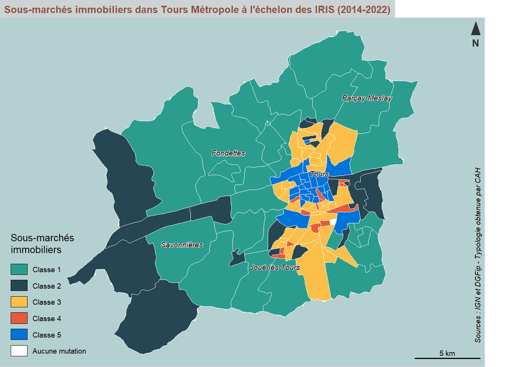

```r
# pour joindre le résultat de la typologie dans la couche des IRIS
IRISDVFCAH <- left_join(IRISTM, IRISCluster, by = "iris_code")

# Paramétrage des marges de la fenêtre pour maximiser l'emprise de la carte
par(mar = c(0, 0, 1.2, 2))

# pour afficher la surface lissée et définir l'habillage de la carte
# Calcul des seuils
bks <- unique(getBreaks(values(cartelissee.raster), method = "q6"))

# Création d'une palette de couleurs (double gradation harmonique)
cols <- c("#2a9c4e", "#77c35c", "#c4e687", "#ffffc0", "#fec981", "#dc292c")

# Affichage des communes de RM et alentours en arrière-plan et centrage de la carte sur Tours Métropole
plot(st_geometry(Communes), lwd = 0.1, col = "grey95", border = "white", bg = "#B5D0D0", xlim = c(st_bbox(IRISTM)[1], st_bbox(IRISTM)[3]), ylim = c(st_bbox(IRISTM)[2], st_bbox(IRISTM)[4]))

# Affichage de la typologie et du contour des IRIS
typoLayer(
  x = IRISDVFCAH,
  var="CLUSIMMO",
  col = c("#2A9D8F","#264653","#fcbf49","#e45c3a","#0074D9"),
  lwd = 0.05,
  border = "white",
  legend.values.order = c("Classe 1",
                          "Classe 2",
                          "Classe 3",
                          "Classe 4",
                          "Classe 5"),
  legend.pos = "bottomleft",
  legend.title.txt = "Sous-marchés \nimmobiliers",
  legend.nodata = "Aucune mutation",
  add = TRUE)

layoutLayer(title = "Sous-marchés immobiliers dans Tours Métropole à l'échelon des IRIS (2014-2022)",
            author = "          Sources : IGN et DGFip - Typologie obtenue par CAH",
            scale = 5, frame = TRUE, col = "#cdd2d4", coltitle = "#8A5543",
            north = TRUE, tabtitle = TRUE, horiz = FALSE)

# Ajouter les étiquettes des communes sélectionnées plus haut
labelLayer(Selection_Communes_TM, txt = "commune", halo = TRUE, bg = "grey90", r = 0.05, cex = 0.6, pos = 3, font = 3, offset = 0)
```

## 1.7.11 Export des Iris contenant la typologie issue de la CAH au format geopackage (pour une utilisation dans un SIG par exemple)

```r
st_write(IRISDVFCAH, "IRISDVFCAH.gpkg", append = FALSE)
```

```
## Deleting layer `IRISDVFCAH' using driver `GPKG'
## Writing layer `IRISDVFCAH' to data source `IRISDVFCAH.gpkg' using driver `GPKG'
## Writing 120 features with 37 fields and geometry type Multi Polygon.
```

# 1.8 Lissage spatial des prix au m² des appartements entre 2014 et 2022 : zoom sur la commune de Tours

## 1.8.1 Préparation du jeu de données

```r
# pour ne garder que la commmune de Tours
CommuneTours <- Communes %>% filter(commune == "Tours")

# pour ne garder que les mutations correspondant à des appartements dans Tours Métropole (dans un premier temps)
MutationsApptTM <- MutationsTM %>% filter(type == "Appartement")

# pour créer une liste d'années, dans l'ordre
MutationsApptTM<-MutationsApptTM[order(MutationsApptTM$annee, decreasing = FALSE), ]
ListAnnees <- unique(MutationsApptTM$annee)

# pour définir comme emprise pour le lissage, l'étendue de Tours avec une zone tampon de 0,5 km autour afin d'englober les mutations limitrophes et réduire l'effet de bord
EmpriseTours <- as.owin(st_buffer(st_geometry(CommuneTours), 500))

# Création d'une palette de couleurs
cols <- c("#f7fcf0", "#f7fcf0", "#e0f3db", "#ccebc5", "#a8ddb5", "#7bccc4", "#4eb3d3", "#2b8cbe", "#0868ac", "#084081", "#08406f")
```

## 1.8.2 Série de cartes lissées montrant l’évolution des prix au m² des appartements calculés directement à partir des mutations à Tours

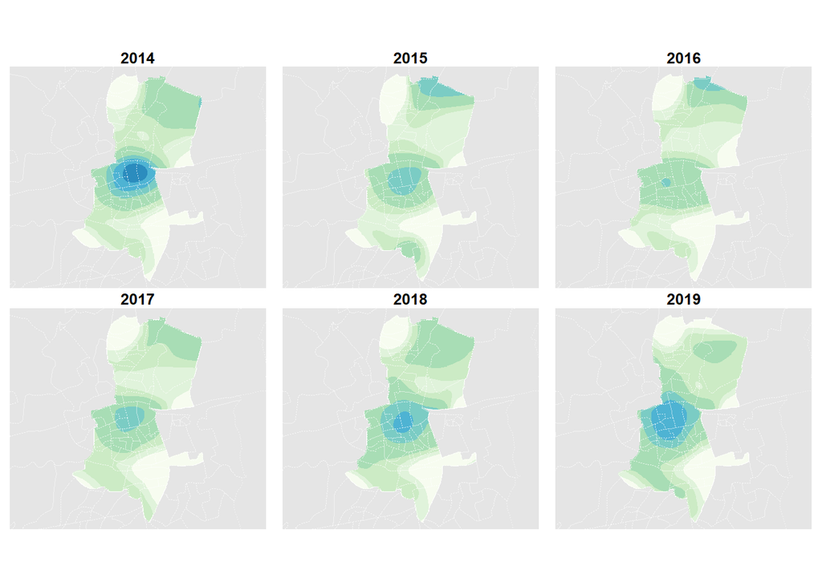

```r
# Paramétrage des marges pour insérer le titre général et les titres de chaque carte
par(oma = c(3.5,0,3,0)+0.1, mar = c(0, 0.5, 1.2, 0.5))

# pour découper la fenêtre en 2 lignes et 3 colonnes (6 années)
par(mfrow = c(2,3))

# boucle pour produire et cartographier une surface lissée par année
for (i in ListAnnees){

  # Recuperation des jeux de données par année
  fichier <- MutationsApptTM[which(MutationsApptTM$annee == i),]

  # pour récupérer les coordonnées des mutations
  pts <- st_coordinates(st_geometry(fichier))

  # pour creer un objet ppp (format spatstat) et y integrer dedans l'emprise et les valeurs a lisser (prix au m²)
  fichier.ppp <- ppp(pts[,1], pts[,2], window = EmpriseTours, marks = fichier$prixm2)

  # pour calculer la surface lissee (rayon lissage : 500 m et resolution spatiale de l'image : 1000m²)
  cartelissee <- Smooth(fichier.ppp, sigma = 500, weights = fichier.ppp$marks, eps = sqrt(1000))

  # Conversion de la surface lissée au format raster
  cartelissee.raster <- rast(cartelissee)
  crs(cartelissee.raster) <- st_crs(CommuneTours)$srid # pour spécifier un SCR à l'objet raster
  cartelissee.raster <- mask(cartelissee.raster, CommuneTours) # découpage sur emprise Tours

  summary(cartelissee.raster)

  # Définition manuelle des seuils
  bks <- c(min(values(cartelissee.raster), na.rm = TRUE), 1600, 2000, 2200, 2400, 2800, 3000, 3200, 3500, 4000, max(values(cartelissee.raster), na.rm = TRUE))

  # reclassification de la surface lissée
  cartelissee.reclass <- classify(cartelissee.raster, rcl = bks)

  # vectorisation de la surface reclassée
  cartelissee.vecteur <- st_as_sf(as.polygons(cartelissee.reclass))

  # trier les valeurs
  cartelissee.vecteur <- cartelissee.vecteur[order(cartelissee.vecteur$lyr.1, decreasing = FALSE), ]

  # Tracer la carte
  plot(st_geometry(CommuneTours), border = "white", bg = "grey90")

  typoLayer(x = cartelissee.vecteur, var = "lyr.1", col = cols, lwd = 0.1,
    border = NA, legend.pos = "n", add = TRUE)

  plot(st_geometry(IRISTM), border = adjustcolor("white", alpha.f = 0.5), lty = 3, lwd = 0.01, add = TRUE)

  title(main = paste("", i, sep = ""))

}
```

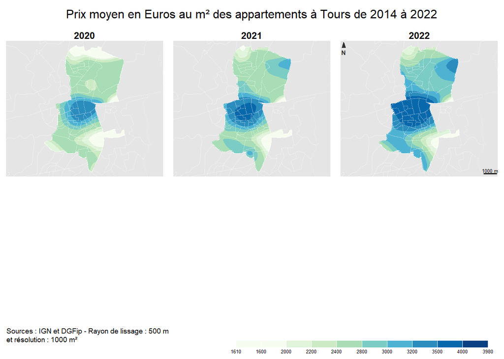

```r
barscale(lwd = 1.5, cex = 0.6, pos = "bottomright", style = "pretty", unit = "m")
cartography::north(pos = "topleft")

# Pour afficher le titre principal et la source
mtext("Prix moyen en Euros au m² des appartements à Tours de 2014 à 2022", cex = 1, side = 3, line = 1, adj = 0.5, outer = TRUE)
mtext("   Sources : IGN et DGFip - Rayon de lissage : 500 m\n   et résolution : 1000 m²", side = 1, line = 1, adj = 0, cex = 0.6, outer = TRUE)

# Affichage de la légende (dans une nouvelle fenêtre graphique)
par(fig = c(0, 1, 0, 1), oma = c(0, 0, 0, 0), mar = c(0, 0, 0, 0), new = TRUE)
plot.new()

legendChoro(
  pos = "bottomright",
  title.txt = "",
  breaks = bks,
  nodata = FALSE,
  values.rnd = -1,
  col = cols,
  border = "white",
  horiz = TRUE
)
```

```r
# Nous pouvons observer une erreur dans le code R, il semblerait que certaine données soient en double, nous avons pourtant essayer de tout changer, nous n'avons pas reussis.
# 2014 connait un pique dans les prix moyen au m2 dans le centre pour les appartements à cause de la création de la ligne de Tram l'année précedente.
```